# Trends in Global Atmospheric Carbon Dioxide

Hoda

11/28/2019

## Data Understanding

This data on monthly global atmospheric carbon dioxide CO2, provided by the Earth System research Laboratory is integral to understanding of the global CO2 dynamics. It gives monthly average of CO2 concentration in parts per million (ppm). The concentration in ppm express dry air mole fraction defined as the number of molecules of carbondioxide divided by the number of all molecules in air, including CO2 itself, after water vapor has been removed.

## Loading the required libraries

```r
suppressPackageStartupMessages(library(tidyverse))
```

## Data Download

We now downlad the global averaged marine surface monthly mean data from the NOAA website [here](https://www.esrl.noaa.gov/gmd/ccgg/trends/gl_data.html)

```r
file_path <- "./data/co2_mm_gl.txt"
if (!file.exists(file_path)) {
dir.create("./data")
url <- "ftp://aftp.cmdl.noaa.gov/products/trends/co2/co2_mm_gl.txt"
download.file(url = url,
destfile = file_path)
}
```

## Reading in the file

We use the read.table function to read in the txt file and skip the first 58 lines of metadata (lines starting with the comment sign). Since we are interested in only the monthly average and trend columns, we select only the two columns and give them the appropriate names

```r
co2_monthly <- read.table("data/co2_mm_gl.txt",skip=58)[,4:5]
names(co2_monthly) <- c("Monthly Avg","Trend")
head(co2_monthly)
```

```
##   Monthly Avg  Trend
## 1      338.45 337.82
## 2      339.15 338.10
## 3      339.48 338.13
## 4      339.87 338.25
## 5      340.30 338.78
## 6      339.86 339.08
```

## Time Series

We now convert to a time series starting month 1 of 1980 with a monthly frequency

```r
co2_mo_ts <- ts(co2_monthly, start=c(1980,1),frequency=12)
head(co2_mo_ts, 10)
```

```
##       Monthly Avg  Trend
##  [1,]      338.45 337.82
##  [2,]      339.15 338.10
##  [3,]      339.48 338.13
##  [4,]      339.87 338.25
##  [5,]      340.30 338.78
##  [6,]      339.86 339.08
##  [7,]      338.33 339.18
##  [8,]      337.11 339.38
##  [9,]      336.95 339.34
## [10,]      337.72 339.06
```

We now use the str() to confirm the object we have to be sure it is a time series.

```r
str(co2_mo_ts)
```

```
##  Time-Series [1:477, 1:2] from 1980 to 2020: 338 339 339 340 340 ...
##  - attr(*, "dimnames")=List of 2
##   ..$ : NULL
##   ..$ : chr [1:2] "Monthly Avg" "Trend"
```

## Plotting

Now we can obtain a plot of our time series object using the function ts.plot()

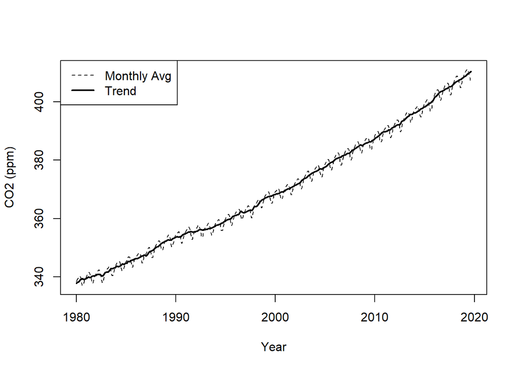

```r
ts.plot(co2_mo_ts,
        type="l",
        lty=2:1,
        lwd=1:2,
        xlab="Year",
        ylab="CO2 (ppm)")
legend('topleft',leg=names(co2_monthly),lty=2:1,lwd=c(1,2))
```

In order to obtain a time series plot for a fraction of time from our original data set, we use the window function in base R

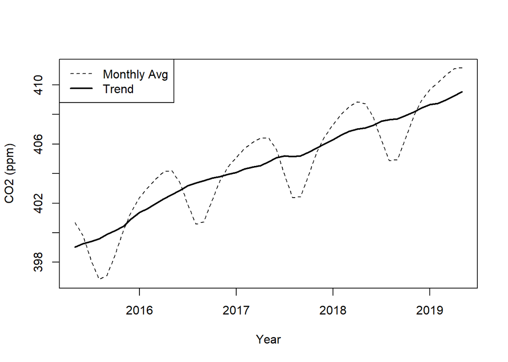

```r
recent_5_yrs <- window(co2_mo_ts,
                       start=c(2015,5),
                       end=c(2019,5))

ts.plot(recent_5_yrs,
        type="l",
        lty=2:1,
        lwd=1:2,
        xlab="Year",
        ylab="CO2 (ppm)")

legend('topleft',
       leg=names(co2_monthly),
       lty=2:1,
       lwd=c(1,2))
```